# Module 3, Lesson 3: Advanced topics in ggplot

In the third lesson of Module 3, you delved into some more advanced topics in ggplot. Layering geoms can tell multiple stories about your data, and we saw that you can create fairly complicated plots with simple code by leveraging concepts such as ‘positional matching’ (a concept you can use for *any* R function, not just `ggplot2` functions) and ‘inheritance’, which is a ‘ggplot2’-specific feature.

You learned how to begin to fine-tune your plots using the `scale` family of functions. And finally, you learned how to make use of the concept of small multiples to create faceted plots.

Open the R project called `Lessons.Rproj` and a blank R script. Then, load the necessary packages into the current R session:

```r
library(healthds)
library(tidyverse)
```

## Layering, positional matching, and inheritance

The standard `ggplot` template is not too onerous to write when creating a single geometric object. For example, a boxplot showing the distribution of weight measurements for each infant is created by

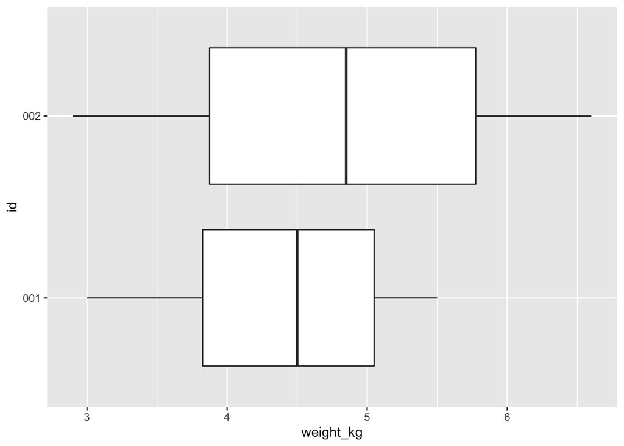

```r
ggplot(data = growth_data) +
  geom_boxplot(mapping = aes(x = weight_kg, y = id))
```

However, when showing boxplots, it is usually good practice to also show the underlying data, especially when your data are small-ish. To do so, we layer on a call to `geom_point`:

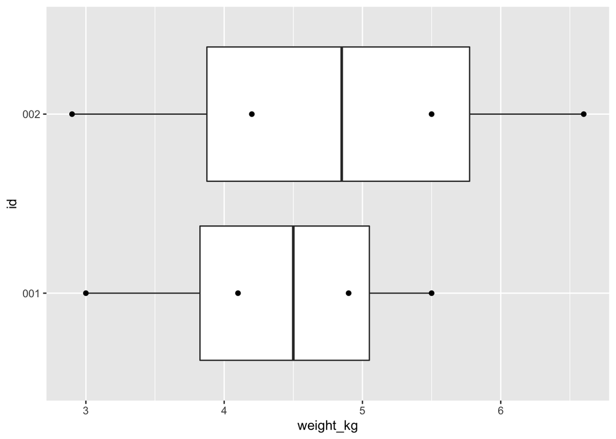

```r
ggplot(data = growth_data) +
  geom_boxplot(mapping = aes(x = weight_kg, y = id)) +
  geom_point(mapping = aes(x = weight_kg, y = id))
```

The code starts to get a bit more complicated looking, and we can trim things down to make it cleaner. First, we can lean on three key facts: (i) the first argument of `ggplot` is `data`; (ii) the first argument of every `geom_<GEOMNAME>` is `mapping`; (iii) and the first and second arguments of `aes` are `x` and `y`, respectively.

Because of these key facts, we can use the R concept of ‘positional matching’, which allows you to specify arguments in their expected order *without naming them*. So, the code below is equivalent to the above code:

```r
ggplot(growth_data) +
  geom_boxplot(aes(weight_kg, id)) +
  geom_point(aes(weight_kg, id))
```

In particular, we don’t need `data =` in the call to `ggplot` because the `data` argument comes first, and therefore `growth_data`, which is now an ‘unnamed’ argument, is matched to `data` by virtue of its position. The same principle applies to justify not needing to write `mapping =`, `x =`, and `y =`. The tradeoff from using positional matching is that you must be sure you have specified the arguments in the exact order that the function expects them. For example, `aes(weight_kg, id)` will give you a different result than `aes(id, weight_kg)`: in the first case `weight_kg` is matched (and therefore mapped) to the `x` aesthetic, and in the second case `weight_kg` is matched and mapped to the `y` aesthetic.

There’s an additional way we can make this code even more concise using ‘inheritance’, which is a `ggplot` specific feature. Inheritance says that we can place inside of `ggplot` all elements of a plot that are intended to be shared in common by every layer. Referring to our figure, one shared element is `data`, and inheritance is already happening for this: the provided `data` object is silently passed down to and used by `geom_boxplot` and `geom_point`. Another shared element are the mapped aesthetics, as specified by `aes(weight_kg, id)`. For this reason, the `ggplot` function has its own mapping argument (which is positioned second in the set of arguments), which, when specified, also gets passed down to the geoms.

Thus, the following code is also equivalent to all of the above code chunks:

```r
ggplot(growth_data, aes(weight_kg, id)) +
  geom_boxplot() +
  geom_point()
```

Now, both the `data` argument (the first argument in our call to `ggplot`, by virtue of positional matching) and the `mapping` argument (the second argument, for the same reasons) get passed down to each of the geoms.

Inheritance is very flexible. If there’s an aesthetic mapping that you want to apply to one geom, you can still incorporate it in the usual way without affeting the inheritance:

```r
ggplot(growth_data, aes(weight_kg, id)) +
  geom_boxplot() +
  geom_label(aes(label = months))
```

[output not shown]

Before continuing, save your work thus far. Save your script as `03_03advancedggplot.R`.

## The scale family of functions

Please note that in the remaining sections of this independent guide, we will still cover all of the same topics discussed in the corresponding guideded practice but with slightly different examples.

The code below creates several plots. We first create a plot showing individual pairs of height-weight measurements, using different colors for each infant id. We then layer on the infant-specific height-weight trajectories. We have done so while taking full advantage of positional matching and inheritance, but we also use a novel feature that we’ve previously not used:

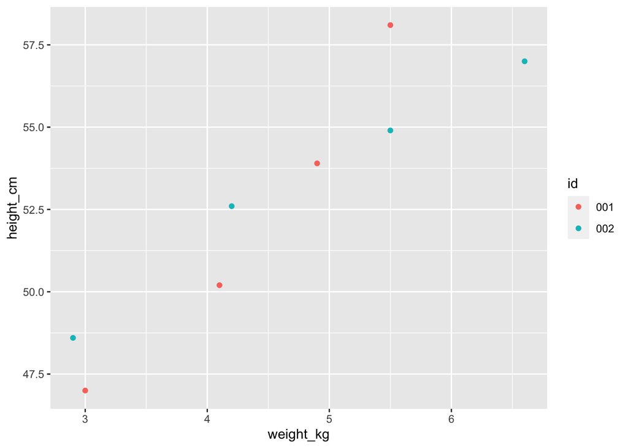

```r
weight_versus_height <-
  ggplot(growth_data, aes(weight_kg, height_cm, color = id)) +
  geom_point()

weight_versus_height
```

We’ve first *assigned* the output from ggplot to an object named `weight_versus_height`. The plot isn’t shown when we make the assignment, but if we type the name of the object in the console and press enter, we view the plot. It is the ‘base’ plot showing just the points.

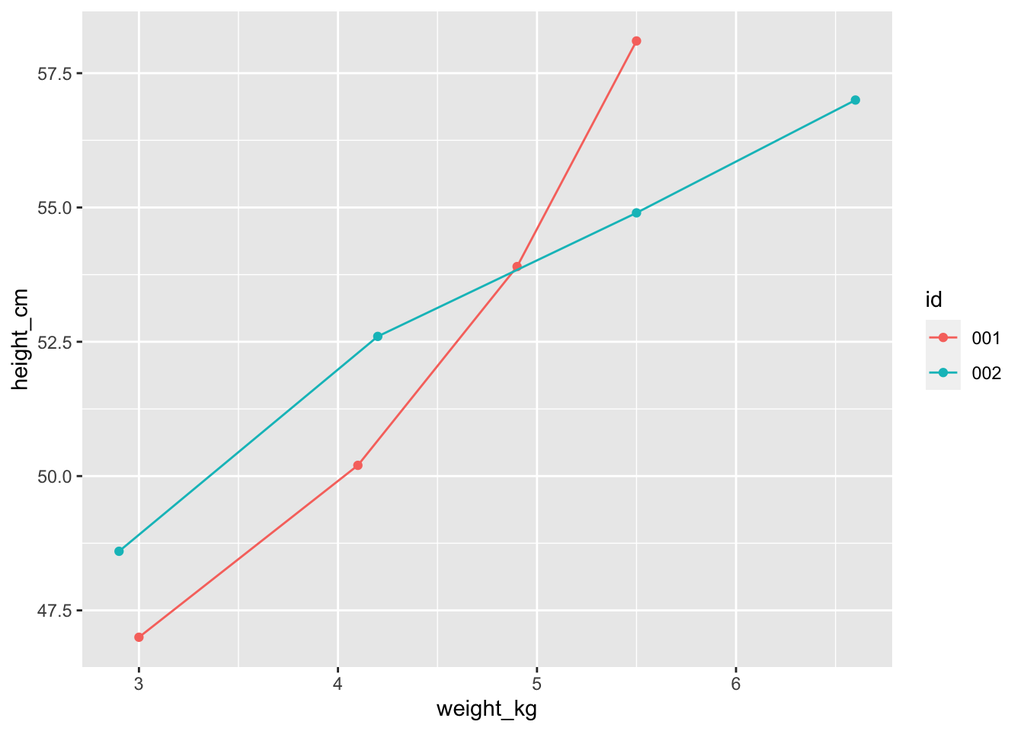

```r
weight_versus_height +
  geom_line(aes(color = id))
```

With this plot object created, we can extend it by adding on other `ggplot` features before printing, as you can see in the chunk above. Specifically, we’ve layered on a call to `geom_line` to show the trajectories.

To make the variable labels more informative, we use the `scale_<AESTHETIC>_continous` and `scale_<AESTHETIC>_discrete` families of functions. Every aesthetic has its own set of scale functions. Within these functions, we can modify the way in which the aesthetic is visualized and presented. So, for example, to change the labels, we would write the following:

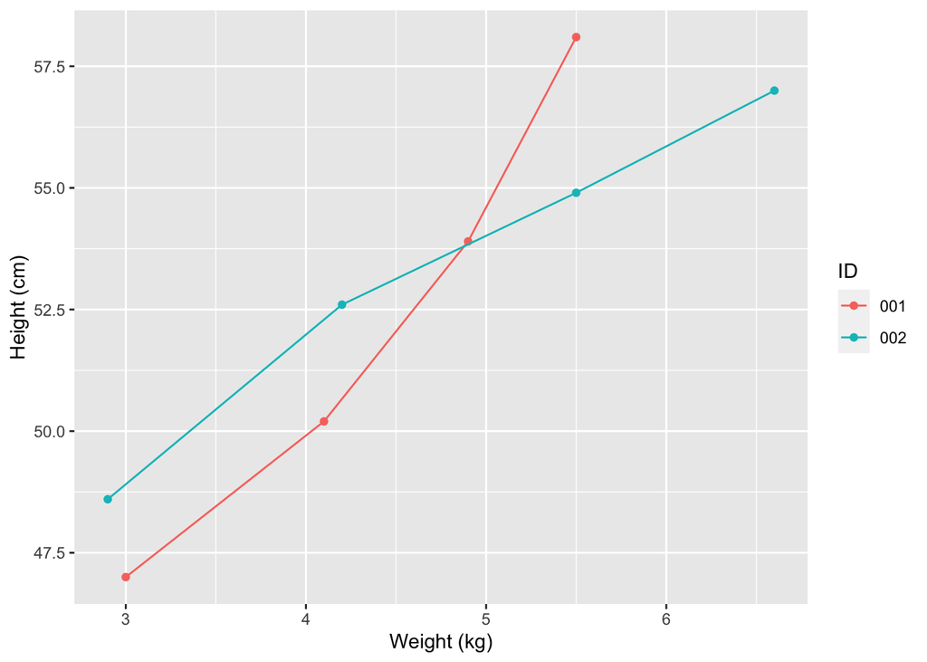

```r
weight_versus_height +
  geom_line() +
  scale_y_continuous(name = "Height (cm)") +
  scale_x_continuous(name = "Weight (kg)") +
  scale_color_discrete(name = "ID")
```

These scale features are added to the base plot just like other functions in `ggplot2`. We have to use the *continuous* versions of these scale functions for the `x` and `y` aesthetics because they are doubles, whereas we have to use the *discrete* version for the `color` aesthetic, because the `id` variable is a character.

The quoted names can be whatever you choose. Take care in writing out these aesthetic names. If you accidentally switch the values of the `name` argument for the `x` and `y` aesthetics, the labels of the x-axis the y-axis will be switched, and the plot will be misleading.

The scale family of functions allows for other useful modifications of your plot. A common example is to change the number or nature of the tick marks along an axis.

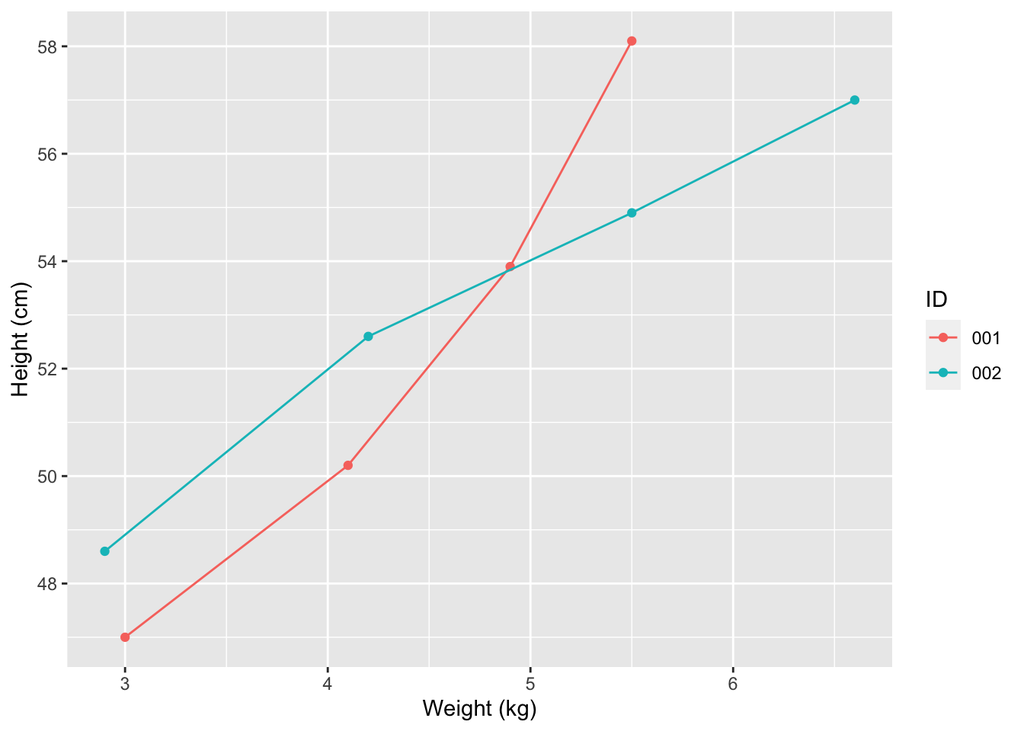

```r
weight_versus_height +
  geom_line() +
  scale_y_continuous(name = "Height (cm)",
                     breaks = seq(from = 48, to = 58, by = 2)) +
  scale_x_continuous(name = "Weight (kg)") +
  scale_color_discrete(name = "ID")
```

Here I am using a function from base R called `seq`, which is used to create a sequence of numbers stored as a vector. In this case, I’m creating a vector that starts at 48, increments by 2 at a time, and continues on in this manner until it would go beyond a number larger than 58, stopping just before this point.

You can alternatively use the concatenate function, `c()`, to provide a custom set of breaks, as in:

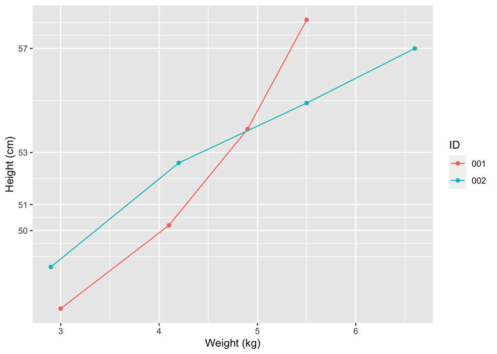

```r
weight_versus_height +
  geom_line() +
  scale_y_continuous(name = "Height (cm)",
                     breaks = c(50, 51, 53, 57)) +
  scale_x_continuous(name = "Weight (kg)") +
  scale_color_discrete(name = "ID")
```

You can also use the `scale` functions to extend the limits of your aesthetics using the `limits` argument. This is most intuitively demonstrated by extending the x- or y-axes. For example, smallest and largest weight measurements are 2.9kg and 6.6kg, respectively, and `ggplot` will automatically set the limits of the x-axis to go just a little bit beyond these most extreme values. We can specify that the limits should instead be 2.5kg and 7.5kg as follows:

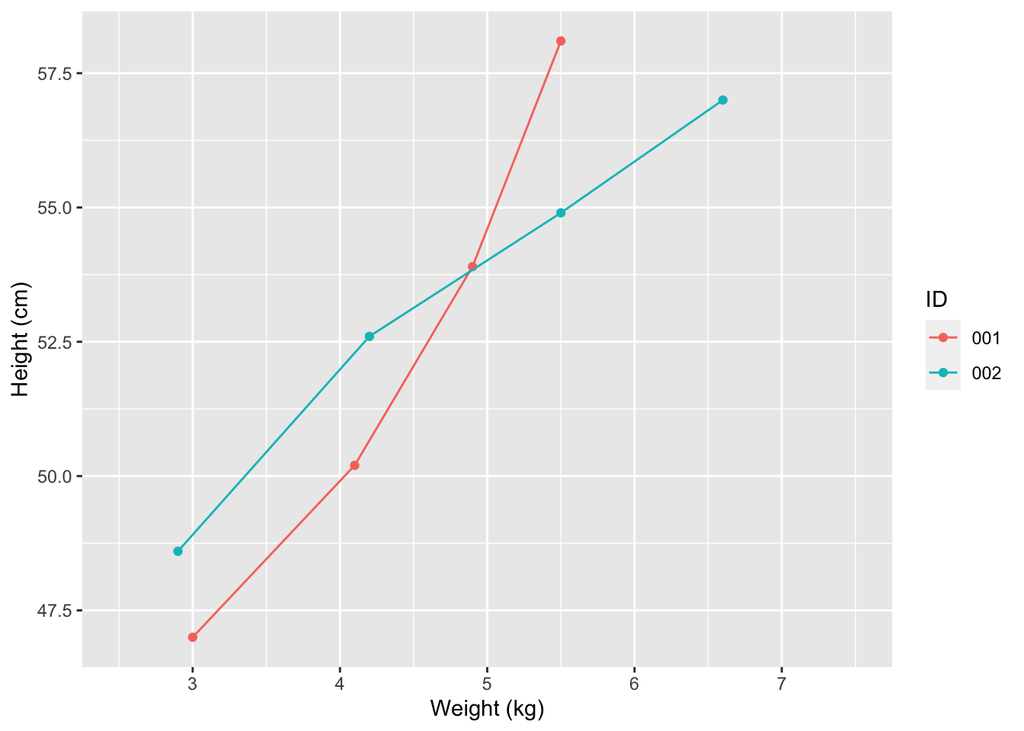

```r
weight_versus_height +
  geom_line() +
  scale_y_continuous(name = "Height (cm)") +
  scale_x_continuous(name = "Weight (kg)",
                     limits = c(2.5, 7.5)) +
  scale_color_discrete(name = "ID")
```

Relative to the base plot, the x-axis is stretched out a bit further on either side.

To see what other features of an aesthetic you can modify with the `scale` family of functions, you should inspect the help page, e.g. `?scale_x_continuous`.

If you only need to change the labels of aesthetics and nothing else, there is a shortcut function provided called `labs`:

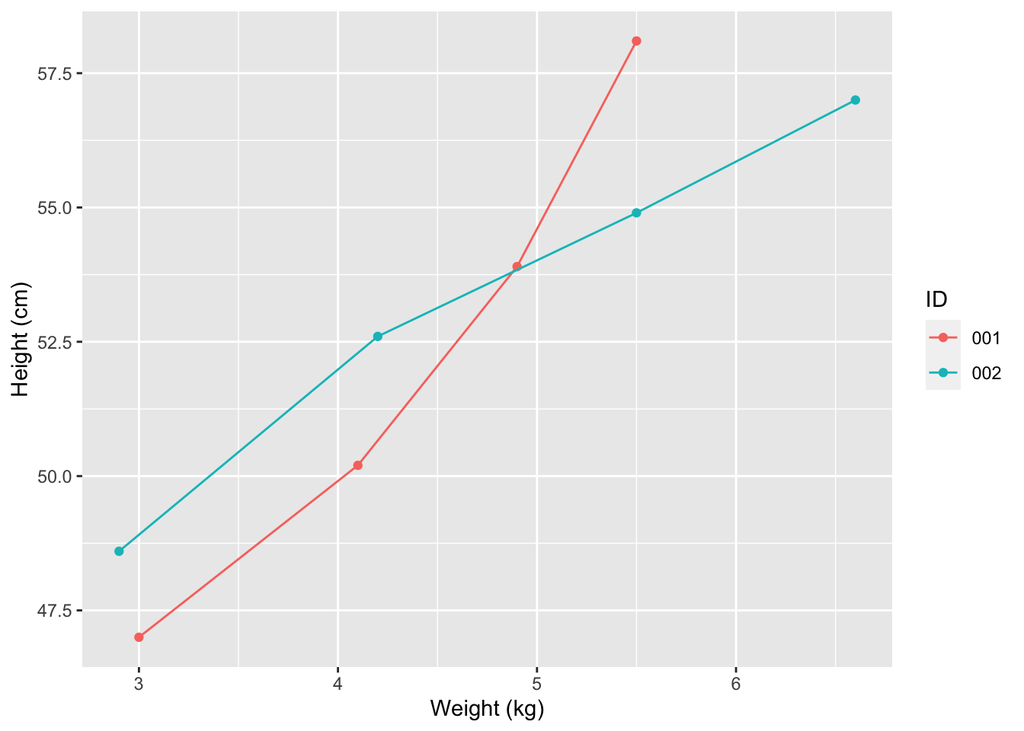

```r
weight_versus_height +
  geom_line() +
  labs(y = "Height (cm)",
       x = "Weight (kg)",
       color = "ID")
```

Save your script at this point using `Cmd+S` or `Ctrl+S` and then keep reading to add more code to this script.

## `facet_grid` and `facet_wrap`

Faceting uses the idea of small multiples to show data across time or space. Faceting is sort of like another aesthetic, allowing you to show your data across multiple panels. To highlight how to facet as well as to demonstrate that we can add any `ggplot` function to an existing plot (and not just `scale` or `geom_` functions as above), run the following code:

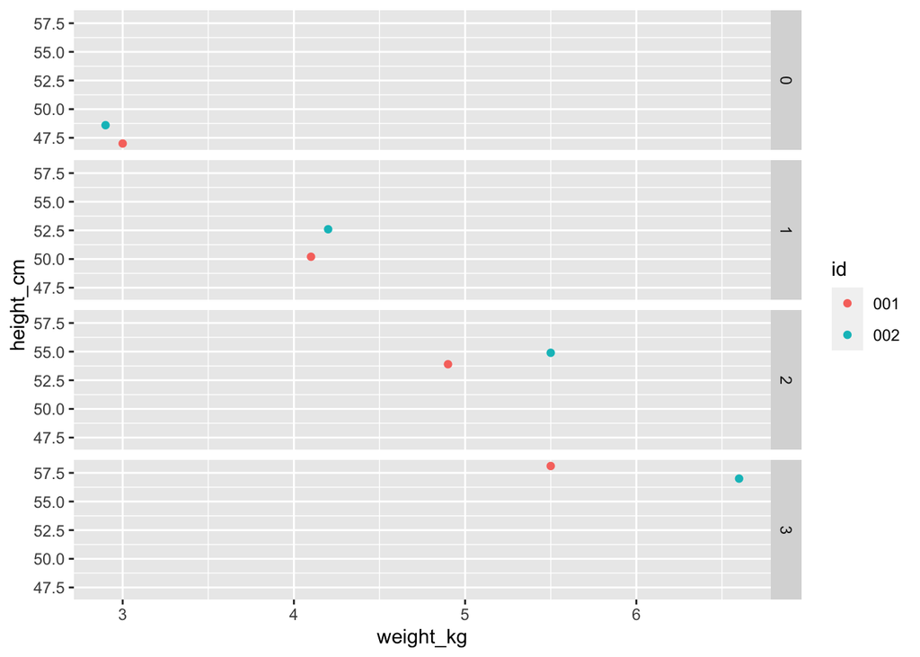

```r
weight_versus_height +
  facet_grid(rows = vars(months))
```

As an aside: this code will only run if you created the `weight_versus_height` object as we did above. Otherwise, you will get an error message from R that states

```
## Error: object 'weight_versus_height' not found
```

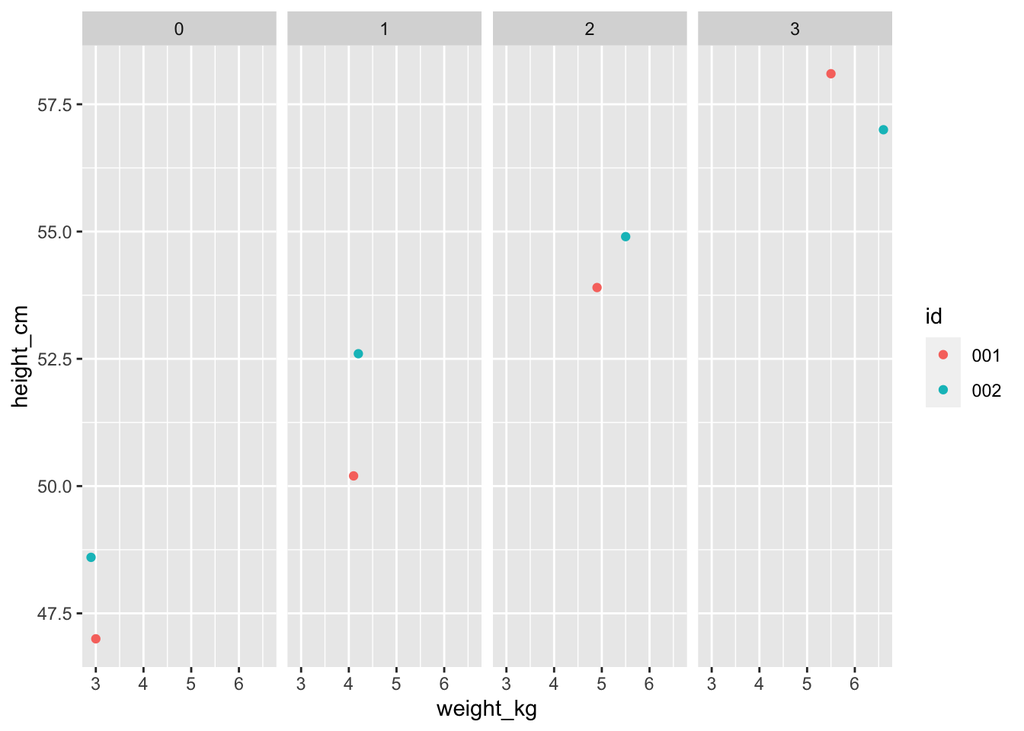

```r
weight_versus_height +
  facet_grid(cols = vars(months))
```

Save your script once again before closing.